# Can we have it all?

2 May 2016

## Intro

Research Question

*"Are career pursuits reconcilable with a happy life?"*

The debate

*'I still strongly believe that women can “have it all” (and that men can too). … But not today, not with the way America’s economy and society are currently structured.'*

Anne-Marie Slaughter - Former director of policy planning for the U.S. State Department

## Research Design

### Data

General Social Survey

- Cross-sectional survey of the adult population in the United States
- Conducted between 1972 to 2014
- Sample size around 60,000

Current Population Survey

- used to generate income percentiles in age and educational groups (reference group income)

## Research Design

Methodology

- Graphical analysis
- Linear Probability Model

Operationalization

- Defining career
- Sample heterogeneity

## Descriptive statistics

## Measures of happiness

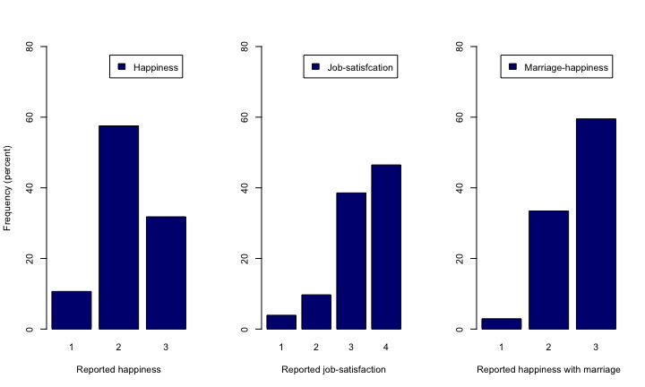

Distribution of reported happiness, job-satisfaction and happiness with marriage

## Gender and age

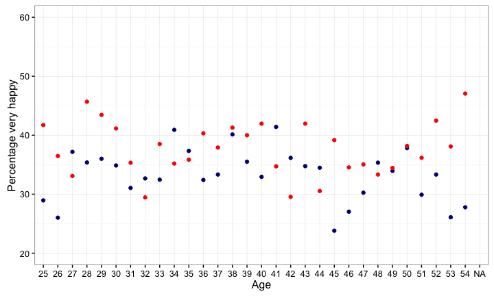

Happiness and age (college educated men and women)

## Labour-market affiliation

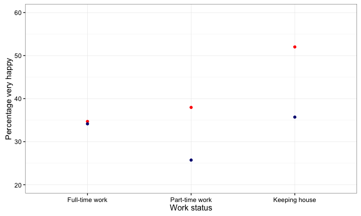

Happiness and labour-market affiliation (college educated men and women)

*Sample restrictions: highly educated men and women (college education)*

## Family status and income

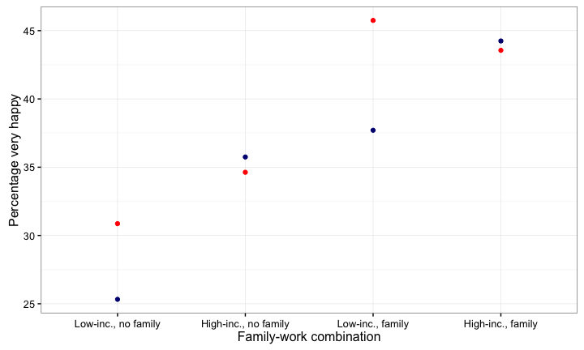

Happiness and family constellation (college educated subsample)

*Sample restrictions: highly educated men and women (college education)*

## Regression analysis

## Model 1: Interaction effects of marriage and job income

take other controls to controls

|  | *Dependent variable:* |  |
| --- | --- | --- |
|  | Very happy |  |
|  | Women | Men |
|  | (1) | (2) |
| High-income | 8.030** | 7.849** |
|  | (3.587) | (3.125) |
| Married | 20.892*** | 18.986*** |
|  | (1.670) | (1.856) |
| Age | -2.445** | 0.375 |
|  | (0.965) | (0.985) |
| Age-squared | 0.025** | -0.008 |
|  | (0.012) | (0.012) |
| High-income*Married | -9.705** | -0.200 |
|  | (4.786) | (3.719) |
| Constant | 83.524** | -13.145 |
|  | (34.495) | (29.980) |
| Year | Yes | Yes |
| Race | Yes | Yes |
| Cohort | Yes | Yes |
| Observations | 4,014 | 3,850 |
| R<sup>2</sup> | 0.061 | 0.055 |
| Adjusted R<sup>2</sup> | 0.051 | 0.044 |
| Residual Std. Error | 47.229 (df = 3970) | 46.217 (df = 3806) |
| F Statistic | 6.035*** (df = 43; 3970) | 5.164*** (df = 43; 3806) |
| *Note:* | p<0.1; p<0.05; p<0.01 |  |

*Sample restrictions: college educated men and women*

## Illustration of interaction effect

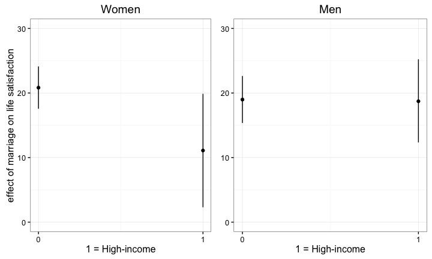

Interaction effects of marriage and job income on life satisfaction

## Model 2: Double-click on married individuals

take other controls to controls

Age -4.078*** 0.683  
(1.387) (1.377)

Age-squared 0.041** -0.015  
(0.017) (0.017)

Constant 151.317*** 7.694  
(46.158) (39.116)

[output not shown]

## Outlook

- Investigate drivers of when overall happiness and life-satisfaction differ
- Regression design where sample is limited to individuals reporting high job-satisfaction
- Investigate effects of work intensity